# R Notebook

$$\\[0.2in]$$
5. Will profits of company increase in 2019?

First, let’s see the trend of profits from 2016 to 2018.

```
Unknown or uninitialised column: `year`.Unknown or uninitialised column: `year`.
```

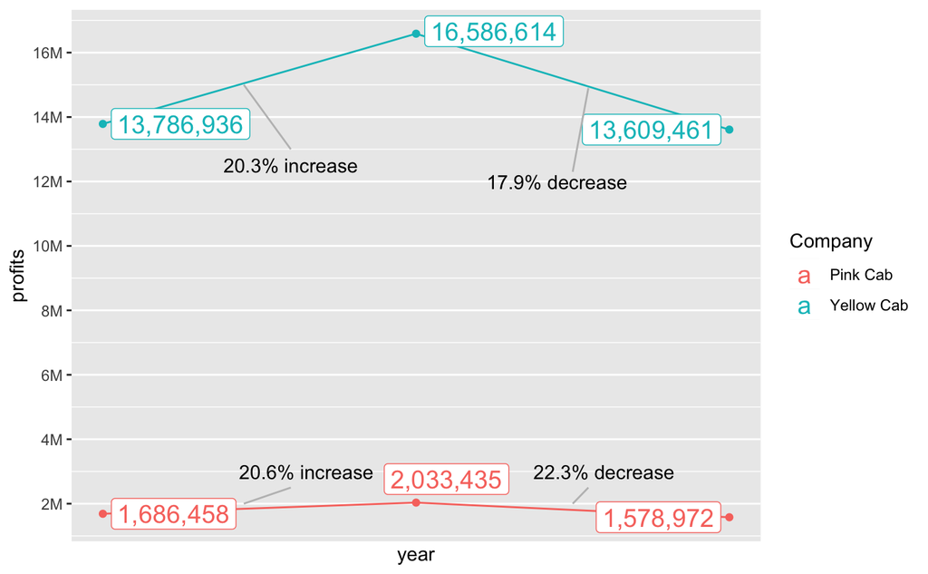

```r
library(ggrepel)
library(scales)
ylab <- c(2,4,6,8,10,12,14,16,18)
combined %>% mutate(year = case_when(.$date >= "2016-01-01" & combined$date <= "2016-12-31" ~ 2016,
                                     .$date >= "2017-01-01" & combined$date <= "2017-12-31" ~ 2017,
                                     .$date >= "2018-01-01" & combined$date <= "2018-12-31" ~ 2018)) %>% group_by(year,Company) %>% summarise(profits=sum(profit)) %>% ungroup() %>% na.omit() %>%ggplot(aes(year, profits, color = Company)) + geom_point() +geom_line() + scale_x_continuous(breaks=unique(combined$year),labels=unique(combined$year)) + scale_y_continuous(labels = paste0(ylab,"M"), breaks = 10^6*ylab) + geom_label_repel(aes(label=comma(round(profits,digits = 0),fill = Company)), size = 5, position = "nudge") +annotate("segment", x=2016.45,xend=2016.6,y=15000000,yend=13000000,color = "grey") + annotate("text", x = 2016.6, y = 12500000, label = "20.3% increase") +annotate ("segment", x=2017.55,xend=2017.5,y=14900000,yend=12300000,color = "grey") + annotate("text", x = 2017.45, y = 12000000, label = "17.9% decrease") + annotate ("segment", x=2017.5,xend=2017.55,y=2000000,yend=2500000,color = "grey") + annotate("text", x = 2017.6, y = 3000000, label = "22.3% decrease") + annotate("segment", x=2016.6,xend=2016.45,y=2500000,yend=2000000,color = "grey") + annotate("text", x = 2016.65, y = 3000000, label = "20.6% increase")
```

$$\\[0.1in]$$

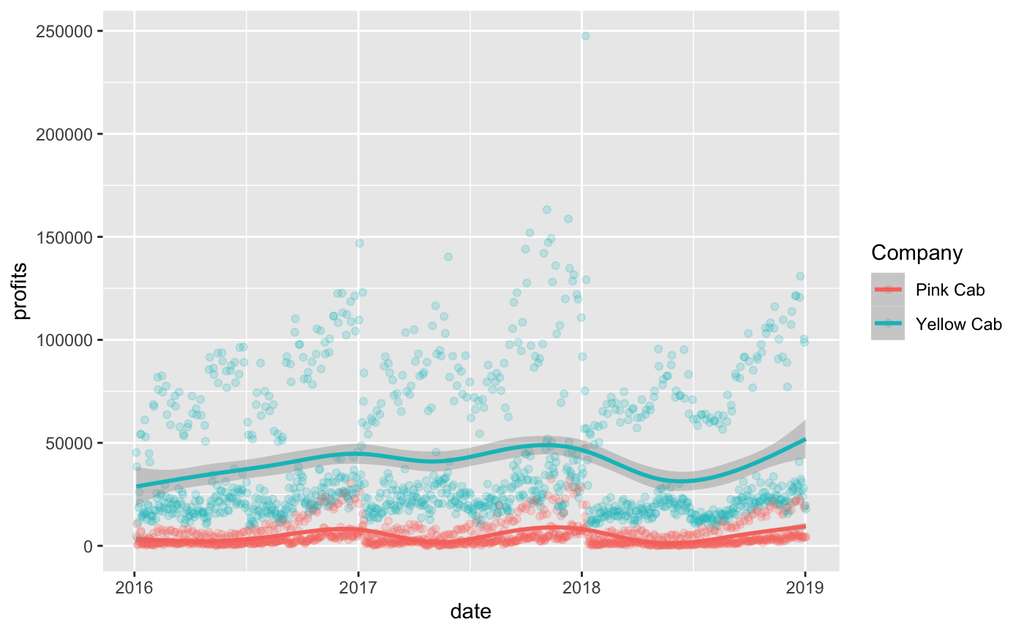

```r
combined %>% group_by(date,Company) %>% summarise(profits = sum(profit)) %>% na.omit() %>% ggplot(aes(date,profits, color = Company)) + geom_point(alpha = 0.2) + geom_smooth()
```

$$\\[0.1in]$$
Let’s forecast the profits with “Prophet” package.

```r
library(StanHeaders)
library(prophet)
pred <- combined %>% group_by(date) %>% summarize(profits = sum(profit))
pred <- pred %>% mutate(ds = pred$date, y = pred$profits)
model <- prophet(pred)
```

```
Disabling daily seasonality. Run prophet with daily.seasonality=TRUE to override this.
```

```r
future <- make_future_dataframe(model, periods = 365)
forecast <- predict(model, future)
dyplot.prophet(model,forecast)
```

[interactive chart not shown]

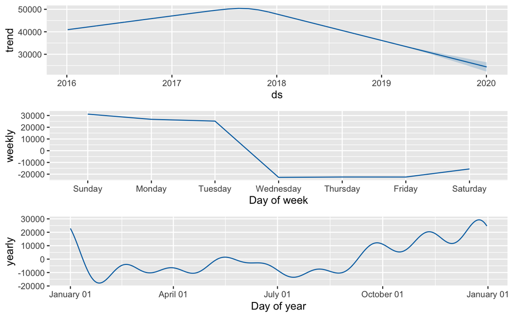

```r
prophet_plot_components(model, forecast)
```

$$\\[0.1in]$$
Results : It seems profits will decrease or even in a good term in 2019 compared to 2018.

$$\\[0.2in]$$

5. Do customers in different cities have preference when choosing taxi company?

Firstly, let’s look into how many rides were taken in each cities.

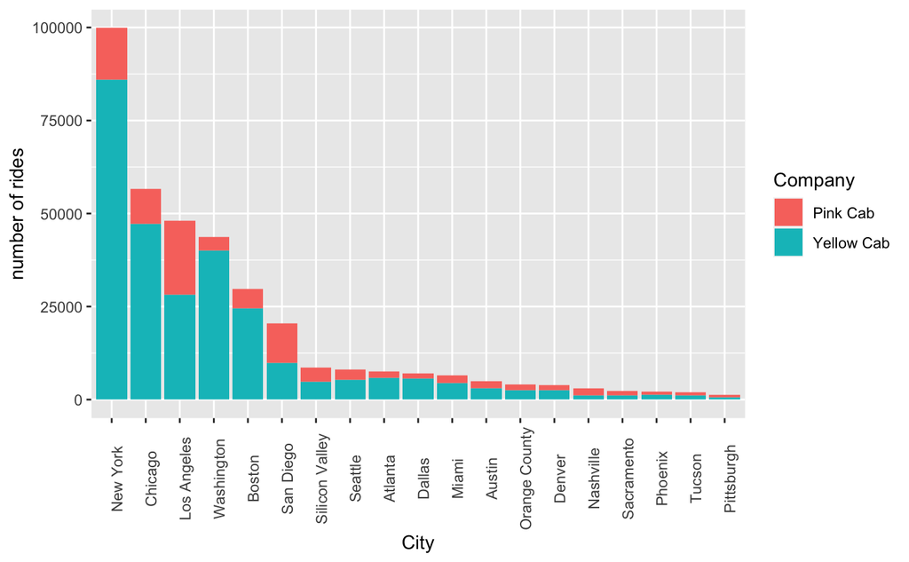

```r
arr_count<- combined %>% group_by(City) %>% summarise(n=n()) %>% arrange(-n)
combined$City <- factor(combined$City, levels = arr_count$City)
combined %>% na.omit() %>% ggplot() + geom_bar(aes(x=City, fill = Company)) +theme(axis.text.x = element_text(angle=90)) + ylab("number of rides")
```

$$\\[0.1in]$$
With below chart, we can see majority of cities’ citizens prefer to take Yellow cab than another.

```r
combined  %>% group_by(City) %>% summarise(yellow = mean(Company == "Yellow Cab"),pink = mean(Company == "Pink Cab" )) %>% arrange(yellow)
```

| City | yellow | pink |
| --- | --- | --- |
| Nashville | 0.3883721 | 0.61162791 |
| Sacramento | 0.4364174 | 0.56358259 |
| San Diego | 0.4791097 | 0.52089028 |
| Pittsburgh | 0.4805788 | 0.51942117 |
| Silicon Valley | 0.5542904 | 0.44570959 |
| Phoenix | 0.5813953 | 0.41860465 |
| Tucson | 0.5862248 | 0.41377525 |
| Los Angeles | 0.5864302 | 0.41356984 |
| Austin | 0.6184641 | 0.38153595 |
| Orange County | 0.6200402 | 0.37995982 |

[output cut: 11 more lines]

$$\\[0.1in]$$

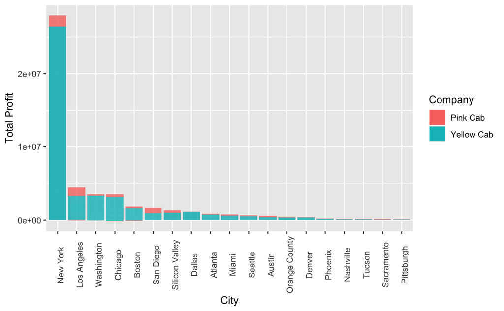

```r
arr <- combined %>% group_by(City) %>% summarise(profits = sum(profit)) %>% arrange(-profits)
combined$City <- factor(combined$City, levels = arr$City)
combined %>% na.omit() %>% ggplot(aes(City, profit, fill = Company),position = "dodge") + geom_col() + theme(axis.text.x=element_text(angle = 90)) + ylab("Total Profit")
```

Result : All cities except Nashville, Sacramento, San Diego, Pittsburgh prefer to take Yellow Cab to Pink Cab. And also those 4 cities’ total profit where like to take Pink Cab more is quite low.

$$\\[0.2in]$$

6. Does taxi fare reflects well the cost of living in each cities?

First, let’s get the average taxi fare per ride for each cites.

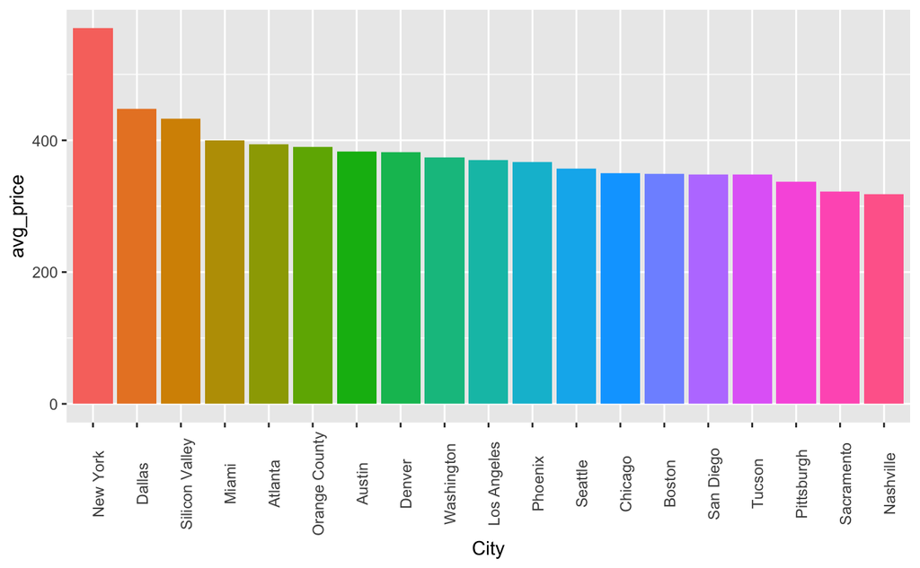

```r
arr_price <- combined %>% group_by(City) %>% summarise(price = mean(price)) %>% arrange(-price)
combined$City <- factor(combined$City, levels = arr_price$City)
combined %>% na.omit() %>% group_by(City) %>% summarise(avg_price = mean(price)) %>% ggplot(aes(City, avg_price,fill = City)) +geom_col() +theme(axis.text.x=element_text(angle = 90)) + theme(legend.position="none")
```

$$\\[0.1in]$$

This is the website address to get the price of living index in US in different cities.  
https://advisorsmith.com/data/coli/

```r
library(readr)
advisorsmith_cost_of_living_index <- read_csv("advisorsmith_cost_of_living_index.csv")
cost_index <- advisorsmith_cost_of_living_index
cost_index<- cost_index %>% filter(City %in% c("New York","Chicago","Los Angeles","Miami","Silicon Valley","Orange County","San Diego","Phoenix","Dallas","Atlanta","Denver","Austin","Seattle","Tucson","San Francisco","Sacramento","Pittsburgh","Washington","Nashville","Boston"))
combined$City <- factor(combined$City, levels = arr_price$City)
cost_index <- cost_index %>% rename(Cost_Index = `Cost of Living Index`)
cost_index <- cost_index %>% select(City, Cost_Index) %>% arrange(-Cost_Index)
cost_index
```

| City | Cost_Index |
| --- | --- |
| San Francisco | 178.6 |
| Los Angeles | 140.6 |
| San Diego | 136.2 |
| Boston | 132.6 |
| New York | 128.0 |
| Seattle | 124.6 |
| Sacramento | 120.3 |
| Washington | 120.1 |
| Denver | 112.1 |
| Miami | 110.1 |

[output cut: 8 more lines]

$$\\[0.1in]$$
Let’s compare the average taxi fare price and cost of living in each cities.

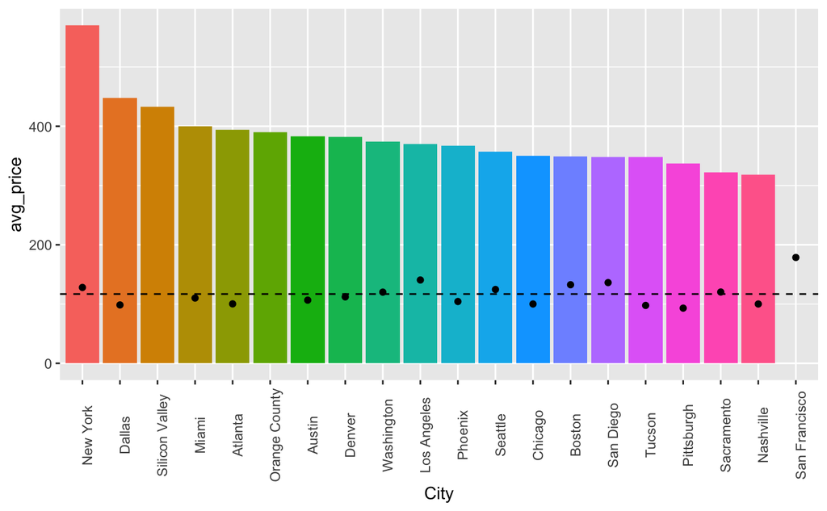

```r
price_index <- combined %>% na.omit() %>% group_by(City) %>% summarise(avg_price = mean(price))
price_index <- full_join(price_index, cost_index)
price_index$City <- factor(price_index$City, levels = arr_price$City)
price_index %>% ggplot() + geom_col(aes(City,avg_price, fill = City)) + geom_point(aes(City, Cost_Index)) + theme(axis.text.x=element_text(angle=90)) + theme(legend.position="none") + geom_hline(yintercept = mean(price_index$Cost_Index,na.rm = TRUE),linetype="dashed")
```

Result : We can adjust the fare of rides according to the cost of living to increase the profit.

$$\\[0.2in]$$
7. Regular customers?

I will define regular customers as someone who took the same color of taxi under same ID.

```r
freq <- combined %>% mutate(year = case_when(.$date >= "2016-01-01" & combined$date <= "2016-12-31" ~ 2016,
                                     .$date >= "2017-01-01" & combined$date <= "2017-12-31" ~ 2017,
                                     .$date >= "2018-01-01" & combined$date <= "2018-12-31" ~ 2018))%>% na.omit() %>% group_by(Company,year,customer_id) %>% summarise(n=n()) %>% arrange(-n)
freq
```

| Company | year | customer_id | n |
| --- | --- | --- | --- |
| Yellow Cab | 2017 | 1766 | 25 |
| Yellow Cab | 2018 | 270 | 22 |
| Yellow Cab | 2017 | 1198 | 21 |
| Yellow Cab | 2017 | 2079 | 21 |
| Yellow Cab | 2018 | 1070 | 21 |
| Yellow Cab | 2018 | 1821 | 21 |
| Yellow Cab | 2017 | 260 | 20 |
| Yellow Cab | 2017 | 549 | 20 |
| Yellow Cab | 2017 | 1103 | 20 |
| Yellow Cab | 2017 | 1739 | 20 |

[output cut: 990 more lines]

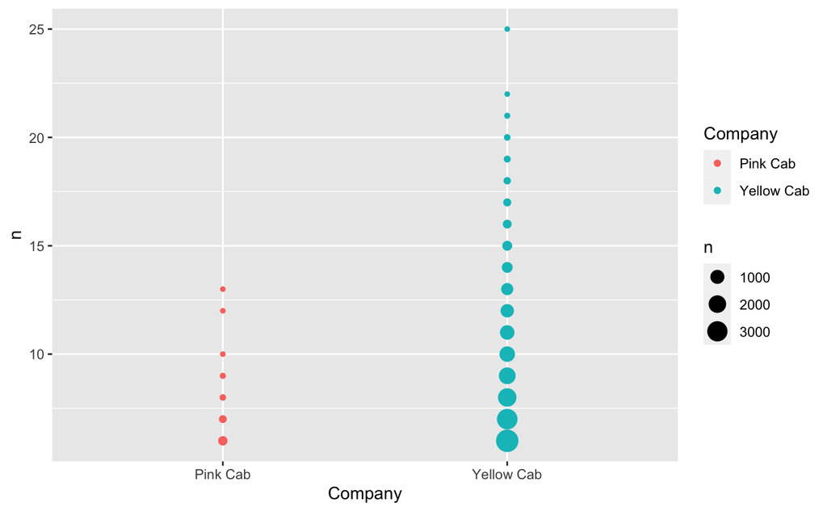

```r
freq %>% filter(n > 5) %>% ggplot(aes(Company,n,color = Company)) + geom_count()
```

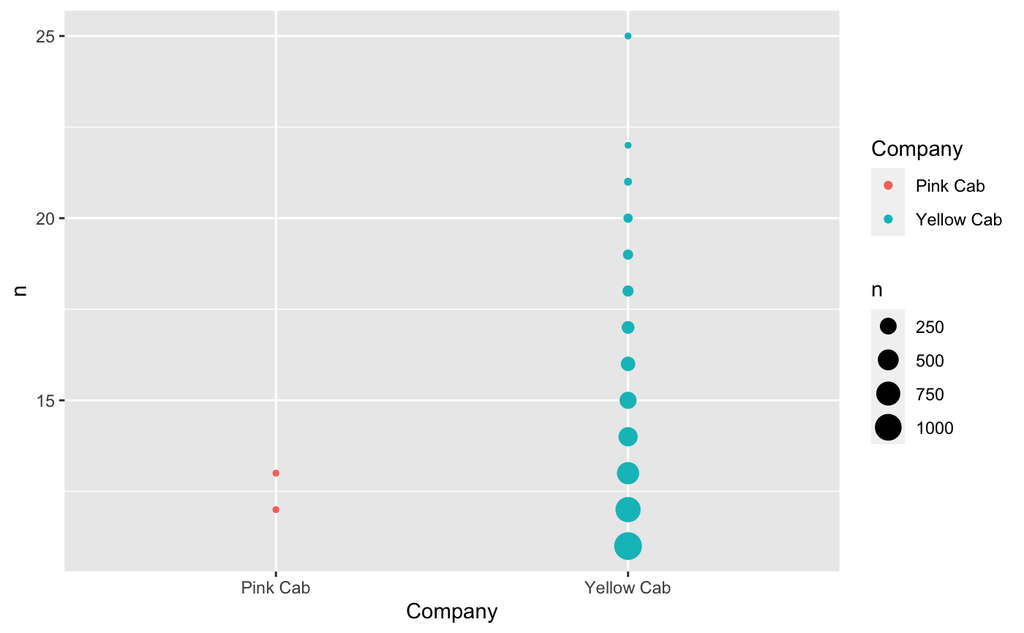

```r
freq %>% filter(n > 10) %>% ggplot(aes(Company,n,color = Company)) + geom_count()
```

Result : Yellow Cab has more Regular customers than Pink Cab.